# Coursework Report

*N* removed NAs: 5

*N* removed <18: 16

**Correct typo age:** 20

*N* total clean: 147

| Group | *N* | *M*<sub>age</sub> | % green |
| --- | --- | --- | --- |
| Control | 72 | 20.47 | 51.85 |
| Experim | 75 | 21.12 | 38.22 |

| Gender | *N* | *M*<sub>age</sub> | % green |
| --- | --- | --- | --- |
| Female | 75 | 20.77 | 45.78 |
| Male | 43 | 20.67 | 45.74 |
| Other | 29 | 21.07 | 41.38 |

**Main analysis results**

**car:**  
χ<sup>2</sup>(1) = 4.91, *p* = .027

**cleaner:**  
χ<sup>2</sup>(1) = 1.12, *p* = .291

**dishwasher:**  
χ<sup>2</sup>(1) = 1.47, *p* = .225

[interactive chart not shown]

[figure not shown]

[interactive chart not shown]

# Coursework Report

Analysing Data, Spring 2020

# Method

## Participants

Summary Table 1 below is produced from our raw data. We can see that 504 people initially participated in the experiment. 255 were female, 153 were male and 96 remained unspecified.

Summary Table

|  | ID | AGE | GENDER | GROUP | SELECTION | PRODUCT |
| --- | --- | --- | --- | --- | --- | --- |
|  | AGCQ : 3 | Length:504 | female:255 | control :252 | luxury:276 | car :168 |
|  | AGSB : 3 | Class :character | male :153 | experimental:251 | green :228 | dishwasher:168 |
|  | AYUV : 3 | Mode :character | other : 96 | experimentl : 1 | NA | cleaner :168 |
|  | BARX : 3 | NA | NA | NA | NA | NA |
|  | BBIM : 3 | NA | NA | NA | NA | NA |
|  | BCNF : 3 | NA | NA | NA | NA | NA |
|  | (Other):486 | NA | NA | NA | NA | NA |

By making use of the is.na function, we can see that 15 observations contain NA values for the age variable.The tibble below shows our data with the is.na function applied to it. A return of “TRUE” in our tibble shows us where any NA values lie.

It would be unsafe to assume that they were 18 or older so we will remove these 15 NA observations from the study.

We reach this number 15 by summing over the age column once the is.na function has been applied. As R assumes the result “TRUE” to be equal to one, the sum gives us a result of 15 NA observations.

[output not shown]

[output cut: 494 more lines]

Further, 48 of these people were under the age of 18 and therefore had to be removed for ethical precautions.

Summary Table 2

|  | ID | AGE | GENDER | GROUP | SELECTION | PRODUCT |
| --- | --- | --- | --- | --- | --- | --- |
|  | AGCQ : 3 | Min. :18.0 | female:225 | control :216 | luxury:243 | car :147 |
|  | AGSB : 3 | 1st Qu.:20.0 | male :129 | experimental:225 | green :198 | dishwasher:147 |
|  | BARX : 3 | Median :20.0 | other : 87 | NA | NA | cleaner :147 |
|  | BBIM : 3 | Mean :20.8 | NA | NA | NA | NA |
|  | BDYI : 3 | 3rd Qu.:22.0 | NA | NA | NA | NA |
|  | BNIW : 3 | Max. :26.0 | NA | NA | NA | NA |
|  | (Other):423 | NA | NA | NA | NA | NA |

The table below shows the average participant age was 21, the oldest participant was 26 and the youngest was 18, giving them an age range of 8 years. The result below shows that the age variable has a standard deviation value of 1.765732. A final total of 441 peoples’ data was included in the results.

Summary of Participant Demographics by Age

| *M*<sub>age</sub> | *SD*<sub>age</sub> | *Min*<sub>age</sub> | *Max*<sub>age</sub> |
| --- | --- | --- | --- |
| 20.8 | 1.77 | 18 | 26 |

The table shown below provides us with an insight into the number and age of participants in the two experimental conditions, broken down by gender.

Summary of Participant Demographics by Experimental Condition

| Gender | Condition | Count | *M*<sub>age</sub> | *SD*<sub>age</sub> |
| --- | --- | --- | --- | --- |
| female | control | 123 | 20.44 | 1.88 |
| female | experimental | 102 | 21.18 | 1.77 |
| male | control | 60 | 20.25 | 1.46 |
| male | experimental | 69 | 21.04 | 1.59 |
| other | control | 33 | 21.00 | 1.68 |
| other | experimental | 54 | 21.11 | 1.84 |

## Design

This research aimed to investigate whether the activation of status motives within individuals influenced their desire for green products, as demonstrated through their choice between purchasing either ‘luxury’ or ‘green’ products.

This study’s independent variable of ‘status’ and its opposing ‘control’ condition were operationalised via the administration and participants’ perusal of either; a ‘status-motive activating’ story or a ‘control’ story. Therefore, participants were recorded as either being ‘experimental’ or ‘control’ in the “Group” variable section of the data. The study’s dependent variable manifests as the participants’ categorically measurable choice to either buy ‘luxury’ or ‘green’ versions of one of the three products: a car, a cleaner or a dishwasher.

Our operational hypothesis therefore states that; there is a relationship between status and peoples’ ‘green’ product purchasing choices, as whether participants choose the ‘green’ or ‘luxury’ versions of products will differ in accordance with whether they experience either the ‘status-motives activation’ or ‘control-motive’ condition.

We will perform the chi-squared statistical analysis in order to test this hypothesis, as it demonstrates the likelihood that the observed frequency distribution is due to chance and measures the accuracy with which the observed data distribution fits the expectant distribution if the variables are independent.

## Results

As can be interpreted by the barplot shown below, our study’s results show that; in the control condition, more ‘green’ products were bought, whilst in the experimental condition, people opted more frequently for the ‘luxury’ products.

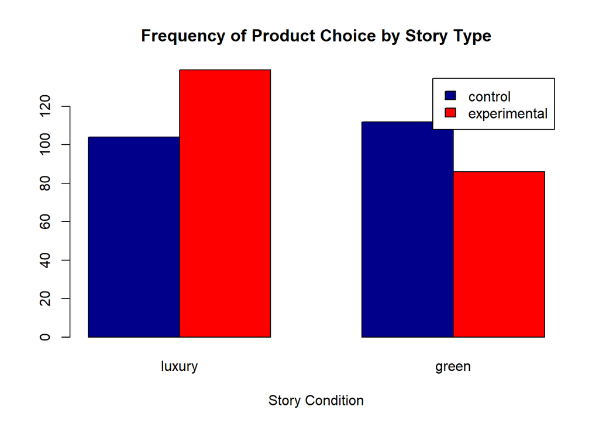

We have produced a two-way frequency table below to show the observed frequencies of either the “luxury” or “green” selection by story type.

|  | luxury | green |
| --- | --- | --- |
| control | 104 | 112 |
| experimental | 139 | 86 |

In order to identify if story condition and product selection are independent of eachother, we have chosen to carry out a Pearson’s Chi-squared test with Yates’s continuity correction.

We propose the following hypothesis:

**H0:** The variables, story condition and product selection are *independent*.

**H1:** The variables, story condition and product selection *relate to eachother*.

In carrying out our Chi-squared test, we compare the expected frequencies to our observed frequencies.

The results are outlined below.

```
##
##  Pearson's Chi-squared test with Yates' continuity correction
##
## data:  data$GROUP and data$SELECTION
## X-squared = 7.7333, df = 1, p-value = 0.005421
```

The calculated value for X-squared is 7.7333.

The degrees of freedom which determines the chi-sqaured distribution, is 1, from which we obtain the p-value. The p-value is a representation of the probability of getting a test statistic this big if the null hypothesis is true.

The Chi-squared results show the p-value to be very small (=0.005421), hence, using a significance level value of 0.05, we may conclude that the null hypothesis **may not be true**.

It is important to note that this does not mean we have evidence to accept our alternative hypothesis completely.

However, this test tells us that it is unlikely that the story condition and product selection variables are independent of eachother. This may allow us to infer that maybe there is a relationship between these two variables.

# Discussion

Such an imminent need for replicable intervention holds much weight when we consider these contrasting conjectures; with the original study embodying the more current thinking - which contemplates the idea that the activation of status motives can result in people shying away from luxury and alternatively selecting self-sacrifice - while our conflicting findings reflect the more traditional approach - which maintains the association between status and preferences for luxury.

However, this study has contributed to an enhanced comprehension of the relationships connecting prosocial behaviour, status and environmental consciousness. It has paved the way for further research to be conducted into whether the stimulation of status motives can be utilised as a viable method for encouraging eco-friendly practices, especially when we take into account Roe, Teislb, Levyc, Russell, Truffer, Markard, & Wüstenhagen’s (2001) assertion that, “Green energy’s future success depends on effective branding and marketing communications strategies designed to enhance consumers’ benefit perception.” Such mechanisms could be authentically incorporated into everyday life via the fields of marketing and environmental sciences, in an attempt to reduce potential pollution and protect the earth in a socially and commercially progressive manner.

In terms of limitations, this study’s specifically restricted 8-year age range bounded our findings significantly, as our results are effectively confined to one age/peer group, around the 18-26 age span. By extension, this means that not only have we been unable to accumulate a broad range of potential behaviours and beliefs but we also cannot generalise our findings to a wider population as our participant sample was not representative and as such, is lacking in ecological validity. This issue of ecological validity can again be additionally recognised in another aspect of the study whereby, participants’ potential perception that the hypothetical ‘buying’ scenarios may not reflect real life purchasing situations should be considered and possibly adapted in prospective study proposals going forward.

# References

Barclay, P. (2004). Trustworthiness and competitive altruism can also solve the “tragedy of the commons.” *Evolution and Human Behavior, 25*, 209–220.

Gintis, H., Smith, E. A., & Bowles, S. (2001). Costly signaling and cooperation. *Journal of Theoretical Biology, 213*, 103–119.

Griskevicius, V., Tybur, J. M., & Van den Bergh, B. (2010). Going green to be seen: Status, reputation, and conspicuous conservation. *Journal of Personality and Social Psychology, 98*(3), 392–404.

Hartmann, P., & Apaolaza-Ibáñez, V. (2012). Consumer attitude and purchase intention toward green energy brands: The roles of psychological benefits and environmental concern.*Journal of Business Research, 65*(9), 1254–1263.